# Ques 1

The transfer function in time domain for the single formant resonator is:

$H(S)=\frac{G}{(S+\sigma_{p}+\Omega_{p})(S+\sigma_{p}-\Omega_{p})}$

Poles are at $S=-\sigma_{p} \pm j\Omega_{p}$

Now we convert this transfer function to discrete domain by using Impulse Invarience Method.

$Z=e^{ST_{s}}$, where $T_{s}$ is the sampling time period.

$Z_{p}=re^{j\theta}$

$r=e^{-\sigma_{p}T_{s}}$ and $\theta= \Omega_{p}T_{s}$

$\Omega_{p}=2\pi F_{i}$ and $\sigma_{p}=\pi B_{i} $

$r_{i}=e^{-B_{i}\pi T}$ and $\theta_{i}=2\pi F_{i}T$

$H(Z)=\frac{k}{1-2r\cos \theta Z^{-1}+r^{2}Z^{-2}}$

Given in Question- $F1(formant frequency)=900Hz, B1(bandwidth)=200Hz$, $F_{s}=16KHz$

From this we calculate, $r=0.9615$ and $\theta=(9/80)\pi$

After putting values of $r$ and $\theta$, we get our Z domain transfer function as:

$H(Z)=\frac{1}{1-1.804Z^{-1}+0.924Z^{-2}}$

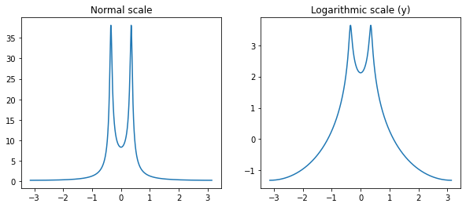

```python
#=========importing required libraries================
import cmath as cm
import numpy as np
import matplotlib.pyplot as plt
# finction for plotting transfer function
def H(z):
    num = 1
    denom=1-1.804*z**(-1)+0.924*z**(-2)
    return num/denom
j=cm.sqrt(-1)
w_range = np.linspace(-np.pi, np.pi,8000)
magnitude= np.abs(H(np.exp(1j*w_range)))
log_magnitude=np.log(np.abs(H(np.exp(1j*w_range))))
fig, axes = plt.subplots(1, 2, figsize=(10,4))

axes[0].plot(w_range, magnitude)
axes[0].set_title("Normal scale")

axes[1].plot(w_range,log_magnitude)
axes[1].set_title("Logarithmic scale (y)")

plt.show()
```

**Getting impulse response from partial fraction and putting $x(n)=\delta(n)$**

$y(n)=\delta(n)*y(n)$

Y(Z)=H(Z)

From transfer function: $Y(Z)=H(Z).X(Z)$

after putting value of H(Z) we get , $Y(Z).(1-1.804Z^{-1}+0.924Z^{-2})=X(Z)$

$y(n)-1.804y(n-1)+0.924y(n-2)=x(n)$

now, when we put x(n)=$\delta(n)$, we get: $y(n)=h(n)$ ,where h(n) is impulse response.

now by putting values of n from 0 to 8, we get

$h(n)=[1, 1.81, 2.33, 2.53, 2.41, 2.01, 1.40, 0.67, -0.09]$

Plotting h(n) below

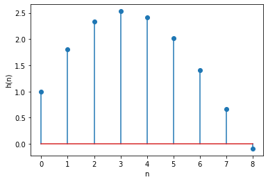

```python
n=np.arange(0,9,1)
h=[1,1.81,2.33,2.53,2.41,2.01,1.40,0.67,-0.09]
plt.stem(n,h)
plt.xlabel('n')
plt.ylabel('h(n)')
plt.show()
```

# Ques 2

$f_{0}=140Hz$

so,$T_{0}=\frac{1}{f_{0}}=\frac{1}{140}=7.143ms$

$f_{s}=16KHz$

$so samples per period,P=\frac{f_{s}}{f_{0}}=\frac{16000}{140}=114.28\approx{114}$

Generating triangular pulse to represent above glottal pulse waveform having peak at every integer multiple of P.

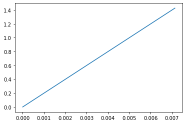

```python
from scipy import signal
from scipy.fftpack import fft, ifft
n = np.linspace(0,0.00714,10)
#     generating triangular pulse of time period 7.14ms
my_signal = 100*(signal.sawtooth(2 * np.pi * 1*n)+1)
plt.plot(n,my_signal)
plt.show()
```

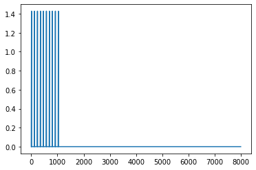

```python
#     generating triangular pulse train at every nP, where n=0,1,2,3.....
imp = signal.unit_impulse(7991, [0,114,228,342,456,570,684,798,912,1026 ])
comb=np.convolve (imp,my_signal)
#     plotting the triangular pulse train
plt.plot(comb)
plt.show()
```

Taking fourier transform of triangular pulse train and multiplying it with filter spectrum earlier generated in question 1

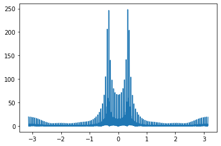

```python
# Taking fourier transform of triangular pulse train
spectrum=fft(comb)
w_range = np.linspace(-np.pi, np.pi, 8000)
# plotting the spectrum of fourier transform of pulse with filter
plt.plot(w_range,abs(spectrum*magnitude))
plt.show()
```

```python
inverse=ifft(abs(spectrum*magnitude))
import IPython.display as ipd
#    playing the sound that is produced
ipd.Audio(abs(spectrum*magnitude),rate=16000)
```

[interactive chart not shown]

After downloading above produced sound, we are calculating its time duration and it is coming to 0.5 sec.

```python
import IPython.display as ipd
from scipy.io import wavfile
from scipy.io.wavfile import read
samplerate, data = read('/download (1).wav')
print('sample rate is',samplerate)
print('no of samples in generated sound',data.shape[0])
#time in sec= total no. of samples/samples per sec
length = data.shape[0] / samplerate
print(f"length = {length}s")
```

```
sample rate is 16000
no of samples in generated sound 8000
length = 0.5s
```

Comment: 1-spectrum of filter was fully visible after multiplying it with triangular pulse train spectrum.

2-I am not able to generate triangular wave properly that is why the generated sound differs from what should get generated. I tried a lot but was not able to tackle this issue within given time.I know it is a crucial step and because of it outputs of all the questions are not coming the one that were desired, I am apologetic for this and learn asa soon as possible.I will discuss my issue with classmates after the assignment submission and learn from this mistake and try to generate everything perfectly in future.

3-Here we are able to hear 0.5 sec sound.

# Ques:3

Varying parameters,

(a): $F_{0} = 120 Hz, F_{1} = 300 Hz, B_{1} = 100 Hz $

$r_{i}=e^{-B_{i}\pi T}$ and $\theta_{i}=2\pi F_{i}T$

$H(Z)=\frac{k}{1-2r\cos \theta Z^{-1}+r^{2}Z^{-2}}$

From this we calculate, r=0.9805 and θ=(3/80)π

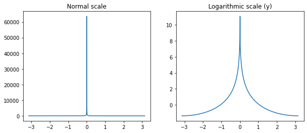

```python
def H(z):
    num = 1
    denom=1-(1.96*z**(-1))+(0.96*z**(-2))
    return num/denom
j=cm.sqrt(-1)
w_range = np.linspace(-np.pi, np.pi,8000)
magnitude= np.abs(H(np.exp(1j*w_range)))
log_magnitude=np.log(np.abs(H(np.exp(1j*w_range))))
fig, axes = plt.subplots(1, 2, figsize=(10,4))

axes[0].plot(w_range, magnitude)
axes[0].set_title("Normal scale")

axes[1].plot(w_range,log_magnitude)
axes[1].set_title("Logarithmic scale (y)")

plt.show()
```

**Ques:2**

(A):

$f_{0}=120Hz$

$f_{s}=16KHz$

$so samples per period,P=\frac{f_{s}}{f_{0}}=\frac{16000}{120}=133.33\approx{133}$

Generating triangular pulse to represent above glottal pulse waveform having peak at every integer multiple of P.

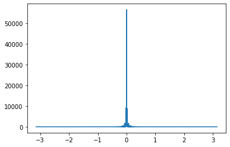

[interactive chart not shown]

```python
n = np.linspace(0, 1, 10)
#     generating triangular pulse
my_signal = (signal.sawtooth(2 * np.pi * 1 * n)+1)
#     generating triangular pulse train at every nP, where n=0,1,2,3.....
imp = signal.unit_impulse(7991, [0, 133, 266,399,532,665,798,931,1064,1197,1330])
comb=np.convolve (imp,my_signal)
# Taking fourier transform of triangular pulse train
spectrum=fft(comb)
w_range = np.linspace(-np.pi, np.pi, 8000)
# plotting the spectrum of fourier transform of pulse with filter
plt.plot(w_range,abs(spectrum*magnitude))
plt.show()
inverse=ifft(abs(spectrum*magnitude))
import IPython.display as ipd
#    playing the sound that is produced
ipd.Audio(inverse,rate=16000)
```

(b): $F_{0} = 120 Hz, F_{1} = 1200 Hz, B_{1} = 200 Hz $

$r_{i}=e^{-B_{i}\pi T}$ and $\theta_{i}=2\pi F_{i}T$

$H(Z)=\frac{k}{1-2r\cos \theta Z^{-1}+r^{2}Z^{-2}}$

From this we calculate, r=0.96 and θ=(3/20)π

After putting values of r and θ , we get our Z domain transfer function as:

$H(Z)=\frac{1}{1−1.71Z^{-1}+0.922Z^{−2}}$

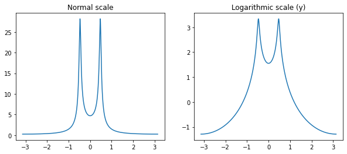

```python
def H(z):
    num = 1
    denom=1-(1.71*z**(-1))+(0.922*z**(-2))
    return num/denom
j=cm.sqrt(-1)
w_range = np.linspace(-np.pi, np.pi,8000)
magnitude= np.abs(H(np.exp(1j*w_range)))
log_magnitude=np.log(np.abs(H(np.exp(1j*w_range))))
fig, axes = plt.subplots(1, 2, figsize=(10,4))

axes[0].plot(w_range, magnitude)
axes[0].set_title("Normal scale")

axes[1].plot(w_range,log_magnitude)
axes[1].set_title("Logarithmic scale (y)")

plt.show()
```

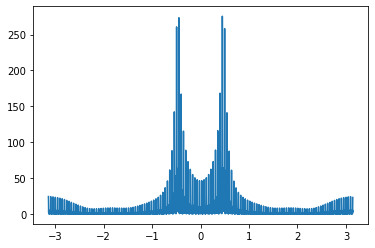

[interactive chart not shown]

```python
n = np.linspace(0, 1, 10)
#     generating triangular pulse
my_signal = (signal.sawtooth(2 * np.pi * 1 * n)+1)
#     generating triangular pulse train at every nP, where n=0,1,2,3.....
imp = signal.unit_impulse(7991, [0, 133, 266,399,532,665,798,931,1064,1197,1330])
comb=np.convolve (imp,my_signal)
# Taking fourier transform of triangular pulse train
spectrum=fft(comb)
w_range = np.linspace(-np.pi, np.pi, 8000)
# plotting the spectrum of fourier transform of pulse with filter
plt.plot(w_range,abs(spectrum*magnitude))
plt.show()
inverse=ifft(abs(spectrum*magnitude))
import IPython.display as ipd
#    playing the sound that is produced
ipd.Audio(inverse,rate=16000)
```

(c): $F_{0} = 180 Hz, F_{1} = 300 Hz, B_{1} = 100 Hz $

$r_{i}=e^{-B_{i}\pi T}$ and $\theta_{i}=2\pi F_{i}T$

$H(Z)=\frac{k}{1-2r\cos \theta Z^{-1}+r^{2}Z^{-2}}$

From this we calculate, r=0.981 and θ=(3/80)π

After putting values of r and θ , we get our Z domain transfer function as:

$H(Z)=\frac{1}{1−1.948Z^{-1}+0.962Z^{−2}}$

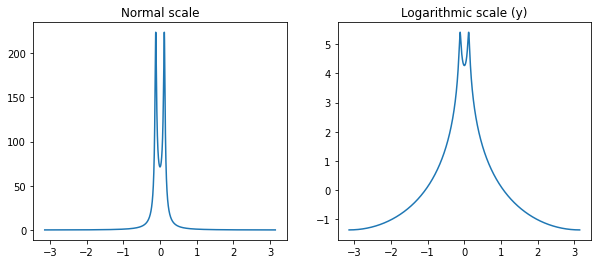

```python
def H(z):
    num = 1
    denom=1-(1.948*z**(-1))+(0.962*z**(-2))
    return num/denom
j=cm.sqrt(-1)
w_range = np.linspace(-np.pi, np.pi,8000)
magnitude= np.abs(H(np.exp(1j*w_range)))
log_magnitude=np.log(np.abs(H(np.exp(1j*w_range))))
fig, axes = plt.subplots(1, 2, figsize=(10,4))

axes[0].plot(w_range, magnitude)
axes[0].set_title("Normal scale")

axes[1].plot(w_range,log_magnitude)
axes[1].set_title("Logarithmic scale (y)")
```

$f_{0}=180Hz$

so,$T_{0}=\frac{1}{f_{0}}=\frac{1}{180}=5.55ms$

$f_{s}=16KHz$

$so samples per period,P=\frac{f_{s}}{f_{0}}=\frac{16000}{180}=88.89\approx{89}$

Generating triangular pulse to represent above glottal pulse waveform having peak at every integer multiple of P.

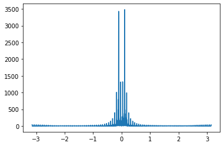

[interactive chart not shown]

```python
n = np.linspace(0, 1, 10)
#     generating triangular pulse
my_signal = (signal.sawtooth(2 * np.pi * 1 * n)+1)
#     generating triangular pulse train at every nP, where n=0,1,2,3.....
imp = signal.unit_impulse(7991, [0,89,178,267,356,445,534,623,712,801,890,
                                 979,1068,1157,1246,1335,1424,1513,1602])
comb=np.convolve (imp,my_signal)
# Taking fourier transform of triangular pulse train
spectrum=fft(comb)
w_range = np.linspace(-np.pi, np.pi, 8000)
# plotting the spectrum of fourier transform of pulse with filter
plt.plot(w_range,abs(spectrum*magnitude))
plt.show()
inverse=ifft(abs(spectrum*magnitude))
import IPython.display as ipd
#    playing the sound that is produced
ipd.Audio(inverse,rate=16000)
```

# Ques:4

Instead of single formant resonator in above questions, here we will generate filter for 3 formant frequencies for generating different vowels.

Vowel "a"- 730, 1090, 2440

For this we will use the cascade combination of three resonant filters. $h_{T}(n)=h_{1}(n)*h_{2}(n)*h_{3}(n)$

$H_{T}(Z)=H_{1}(Z).H_{2}(Z).H_{3}(Z)$

$F_{i}=730Hz, 1090Hz, 2440Hz$ and $B_{i}=100Hz$

$r_{i}=e^{-B_{i}\pi T}$ and $\theta_{i}=2\pi F_{i}T$

$H(Z)=\frac{k}{1-2r\cos \theta Z^{-1}+r^{2}Z^{-2}}$

$Bandwidth=100Hz$

$ For F_{i}=730Hz$

From this we calculate, r=0.98 and θ=0.2867

$For F_{i}=1090Hz$

From this we calculate, r=0.98 and θ=0.428

$For F_{i}=2440Hz$

From this we calculate, r=0.98 and θ=0.958

After putting values of r and θ , we get our Z domain transfer function as:

$H(Z)=(\frac{1}{1−1.879Z^{-1}+0.9604^{−2}}).(\frac{1}{1−1.783Z^{-1}+0.9604Z^{−2}}).(\frac{1}{1−1.127Z^{-1}+0.9604Z^{−2}})$

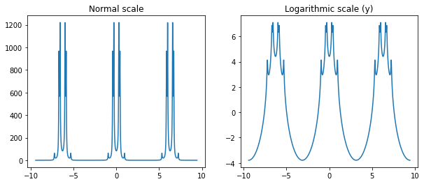

```python
def H(z):
    num = 1
    denom=(1-(1.879*z**(-1))+(0.9604*z**(-2)))*(1-(1.783*z**(-1))+(0.9604*z**(-2)))*(1-(1.127*z**(-1))+(0.9604*z**(-2)))
    return num/denom
j=cm.sqrt(-1)
w_range = np.linspace(-3*np.pi, 3*np.pi,8000)
magnitude= np.abs(H(np.exp(1j*w_range)))
log_magnitude=np.log(np.abs(H(np.exp(1j*w_range))))
fig, axes = plt.subplots(1, 2, figsize=(10,4))

axes[0].plot(w_range, magnitude)
axes[0].set_title("Normal scale")

axes[1].plot(w_range,log_magnitude)
axes[1].set_title("Logarithmic scale (y)")

plt.show()
```

We need to generate two different pitches.

(a): $F_{0}=120Hz$

so,$T_{0}=\frac{1}{f_{0}}=\frac{1}{120}=8.33ms$

$f_{s}=16KHz$

$so samples per period,P=\frac{f_{s}}{f_{0}}=\frac{16000}{120}=133.33\approx{133}$

Generating triangular pulse to represent above glottal pulse waveform having peak at every integer multiple of P.

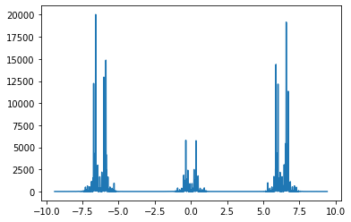

[interactive chart not shown]

```python
n = np.linspace(0, 1, 10)
#     generating triangular pulse
my_signal = (signal.sawtooth(2 * np.pi * 1 * n)+1)
#     generating triangular pulse train at every nP, where n=0,1,2,3.....
imp = signal.unit_impulse(7991, [0, 133, 266,399,532,665,798,931,1064,1197,1330])
comb=np.convolve (imp,my_signal)
# Taking fourier transform of triangular pulse train
spectrum=fft(comb)
w_range = np.linspace(-3*np.pi, 3*np.pi, 8000)
# plotting the spectrum of fourier transform of pulse with filter
plt.plot(w_range,abs(spectrum*magnitude))
plt.show()
inverse=ifft(abs(spectrum*magnitude))
import IPython.display as ipd
#    playing the sound that is produced
ipd.Audio(inverse,rate=16000)
```

(b): $F_{0}=220Hz$

so,$T_{0}=\frac{1}{f_{0}}=\frac{1}{220}=4.54ms$

$f_{s}=16KHz$

Generating triangular pulse to represent above glottal pulse waveform having peak at every integer multiple of P.

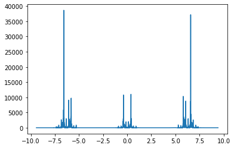

[interactive chart not shown]

```python
n = np.linspace(0, 1, 10)
#     generating triangular pulse
my_signal = (signal.sawtooth(2 * np.pi * 1 * n)+1)
#     generating triangular pulse train at every nP, where n=0,1,2,3.....
imp = signal.unit_impulse(7991, [0, 73, 146,219,292,365,438,511,584,657,730,803,
                                 876,949,1022,1095,1168,1241,1314])
comb=np.convolve (imp,my_signal)
# Taking fourier transform of triangular pulse train
spectrum=fft(comb)
w_range = np.linspace(-3*np.pi, 3*np.pi, 8000)
# plotting the spectrum of fourier transform of pulse with filter
plt.plot(w_range,abs(spectrum*magnitude))
plt.show()
inverse=ifft(abs(spectrum*magnitude))
import IPython.display as ipd
#    playing the sound that is produced
ipd.Audio(inverse,rate=16000)
```

# Ques:4

Vowel "i" 270, 2290, 3010

For this we will use the cascade combination of three resonant filters. $h_{T}(n)=h_{1}(n)*h_{2}(n)*h_{3}(n)$

$H_{T}(Z)=H_{1}(Z).H_{2}(Z).H_{3}(Z)$

$F_{i}=270Hz, 2290Hz, 3010Hz$ and $B_{i}=100Hz$

$r_{i}=e^{-B_{i}\pi T}$ and $\theta_{i}=2\pi F_{i}T$

$H(Z)=\frac{k}{1-2r\cos \theta Z^{-1}+r^{2}Z^{-2}}$

$Bandwidth=100Hz$

$ For F_{i}=270Hz$

From this we calculate, r=0.98 and θ=0.1060

$For F_{i}=2290Hz$

From this we calculate, r=0.98 and θ=0.899

$For F_{i}=3010Hz$

From this we calculate, r=0.98 and θ=1.182

After putting values of r and θ , we get our Z domain transfer function as:

$H(Z)=(\frac{1}{1−1.949Z^{-1}+0.9604^{−2}}).(\frac{1}{1−1.219Z^{-1}+0.9604Z^{−2}}).(\frac{1}{1−0.743Z^{-1}+0.9604Z^{−2}})$

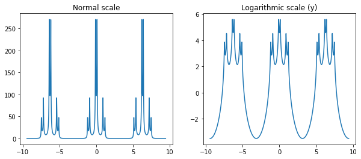

```python
def H(z):
    num = 1
    denom=(1-(1.949*z**(-1))+(0.9604*z**(-2)))*(1-(1.219*z**(-1))+(0.9604*z**(-2)))*(1-(0.743*z**(-1))+(0.9604*z**(-2)))
    return num/denom
j=cm.sqrt(-1)
w_range = np.linspace(-3*np.pi, 3*np.pi,8000)
magnitude= np.abs(H(np.exp(1j*w_range)))
log_magnitude=np.log(np.abs(H(np.exp(1j*w_range))))
fig, axes = plt.subplots(1, 2, figsize=(10,4))

axes[0].plot(w_range, magnitude)
axes[0].set_title("Normal scale")

axes[1].plot(w_range,log_magnitude)
axes[1].set_title("Logarithmic scale (y)")

plt.show()
```

For $F_{0}=120Hz$

P=133(approx)

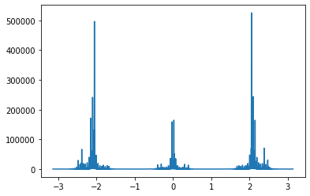

[interactive chart not shown]

```python
n = np.linspace(0, 0.00714, 10)
#     generating triangular pulse
my_signal = 100*(signal.sawtooth(2 * np.pi * 16000 * n)+1)
#     generating triangular pulse train at every nP, where n=0,1,2,3.....
imp = signal.unit_impulse(7991, [0, 133, 266,399,532,665,798,931,1064,1197,1330])
comb=np.convolve (imp,my_signal)
#    Taking fourier transform of triangular pulse train
spectrum=fft(comb)
w_range = np.linspace(-np.pi, np.pi, 8000)
#    plotting the spectrum of fourier transform of pulse with filter
plt.plot(w_range,abs(spectrum*magnitude))
plt.show()
inverse=ifft(abs(spectrum*magnitude))
import IPython.display as ipd
#    playing the sound that is produced
ipd.Audio(inverse,rate=16000)
```

For $F_{0}=220Hz$

P=73(approx)

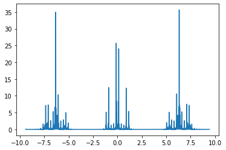

[interactive chart not shown]

```python
n = np.linspace(0, 0.00714, 10)
#     generating triangular pulse
my_signal = (signal.sawtooth(2 * np.pi * 1 * n)+1)
#     generating triangular pulse train at every nP, where n=0,1,2,3.....
imp = signal.unit_impulse(7991, [0, 73, 146,219,292,365,438,511,584,657,730,803,
                                 876,949,1022,1095,1168,1241,1314])
comb=np.convolve (imp,my_signal)
# Taking fourier transform of triangular pulse train
spectrum=fft(comb)
w_range = np.linspace(-3*np.pi, 3*np.pi, 8000)
# plotting the spectrum of fourier transform of pulse with filter
plt.plot(w_range,abs(spectrum*magnitude))
plt.show()
inverse=ifft(abs(spectrum*magnitude))
import IPython.display as ipd
#    playing the sound that is produced
ipd.Audio(inverse,rate=16000)
```